# Statistics for Data Science - Homework 3

Barba Paolo, Candi Matteo

#### Purpose and Statistical tools used

The goal of the project is to perform Friedman’s procedure as a proxy of multiple studies and apply it to fMRI (functional magnetic resonance imaging) data in order to test whether the data from td (typically development) subjects and asd (autism spectrum disorder) subjects came from the same distribution or not. In order to reach this goal we used statistical tools such as machine learning algorithms and two-sample Hypothesis testing.

## **Exercise 3**

#### Two sample hypothesis test:

Friedman’s procedure is used for solving two-sample hypothesis testing when each observation consists of many measured attributes $x_{i} = (x_{i_1}, x_{i_2} . . . x_{i_{M}})$ and $z_{i} = (z_{i_1}, z_{i_2} . . . z_{i_{M}})$ where M is the dimensionality of the dataset and we have $n_{0}$ samples for $\underline{x}$ and $n_{1}$ samples for $\underline{z}$. We create then a hypothesis system as the following:

$$\begin{equation}
\begin{cases}
H_{0}: F_{x} = F_{z}\\ H_{1}: F_{x} \neq F_{z}
\end{cases}
\end{equation}$$

Since the distribution we want to compare is multivariate, there are not a variety of procedures that can compare directly. The idea then, is to perform classification machine learning algorithm as logistic regression, compute the scores of the observed data $\underline{s_{x}}$ and $\underline{s_{z}}$ and compare the univariate distribution using a two-sample hypothesis test as the Kolmogorov-Smirnov test. So the hypothesis system would be as the following:

$$\begin{equation}
\begin{cases}
H_{0}: F_{s_{x}} = F_{s_{z}}\\ H_{1}: F_{s_{x}} \neq F_{s_{z}}
\end{cases}
\end{equation}$$

The take out the distribution under the null hypothesis we lead the following procedure

1. Randomly permute the group label
2. Train classifier (Logistic regression in our case)
3. Compute the scores of the observations
4. Compute the test statistic (Kolmogorov-Smirnov in our case)
5. Repeat P times

After this procedure, we obtain a set of statistics test $\underline{t} = {t_{1} \dots t_{n}}$.

Under $H_{0}$, the entire data vector ${\underline{x} ,\underline{z}}$ is an $i.i.d$ sample from a single distribution F, the group identity is exchangeable. In the following, we work under the permutation null distribution, which places $\frac{1}{(n_{0} + n_{1})!}$ probability of each of the permutation of the group labels.

Then the observed statistics $\hat{t}$ is equally likely to be anywhere in $\underline{t}$.

We can compute the p-value $p = \frac{1}{N} \sum_{j=1}^N \mathbb{I}(t_j \geqslant \hat{t}) = \{\text{proportion of permuted statistics larger than the observed one}\}$ setting the decision rule in order to reject the null hypothesis if the value of $p$ is lower than $\alpha$.

#### Goodness of fit test:

The two-sample hypothesis test can be turned into a goodness of fit test assuming that the sample $\underline{z}$ came from a reference distribution (Say $F$). We can set up the following hypothesis system:

$$\begin{equation}
\begin{cases}
H_{0}: F_{x} = F\\ H_{1}: F_{x} \neq F
\end{cases}
\end{equation}$$

In the goodness of fit hypothesis test, only one sample $\underline{x} = \{ x_{i1} \dots x_{iM} \}_{i =1}^{N}$ is available and the purpose is to test if this sample came from the reference distribution $F$. The distributions are still multivariate and we can use a classifier to reduce multivariate goodness of fit test into a univariate one. The hypothesis system change as the following:

$$\begin{equation}
\begin{cases}
H_{0}: F_{s_{x}} = F_{s}\\ H_{1}: F_{s_{x}} \neq F_{s}
\end{cases}
\end{equation}$$

To perform the above test it is still possible to use the Kolmogorov-Smirnov test. In order to get out the distribution of the Kolmogorov statistics under the null the hypothesis we can set up a Monte Carlo simulation as the following:

1. Drawn a sample $z_{i}$ of size $n_{1}$ from $p_{0}$.
2. Use them with the actual data to train the classification model and compute the scores.
3. Compute the statistics test between the two scores sample.
4. Repeat P times.

After this procedure, we obtain a set of statistics test $\underline{t} = {t_{1} \dots t_{n}}$ that can be used as the distribution of statistic test under the null hypothesis. So we can build the reject region $R_{\alpha}$ as the values of the test statistic greater than a threshold equal $1 - \alpha$ quantile of the distribution. We reject with significance level $\alpha$ if the observed statistics are greater than the threshold.

We can compute the p-value $p = \frac{1}{N} \sum_{j=1}^N \mathbb{I}(t_j \geqslant \hat{t}) = \{\text{proportion of permuted statistics larger than the original}\}$ setting the decision rule to reject the null hypothesis if the value of $p$ is lower than $\alpha$.

```r
# Take random sample from a multi-normal distribution.
Take_sample_normal <- function(n, mu, sigma, label){
  x <- mvrnorm(n, mu, sigma)    # Random generate from a multivariate normal
  x <- as.data.frame(cbind(x, label))   # add label
  colnames(x[length(colnames(x))]) <- "label"   # col label

  return(x)
}

# Apply Friedman procedure.
Friedman_procedure <- function(P,x_data , z_data , permut = FALSE){
  x_fri <- x_data       # Copy the data
  z_p <- z_data         # copy the z data
  kolm_t <- rep(NA, P)  # Pre-set the Kolmogorov-Smirnov statistic
  labels <- c(rep(0,n0),rep(1,n1))   # Set of the label
  for(i in 1:P){                     # Loop
    print(i)
    if(permut == F){                 # Check goodnees of fit
      z_p <- Take_sample_normal(n1, mu, sigma, label =1)  # Sample under the null F
      }
    if(permut == T){                 # Two sample test
    idx <- sample(x = 1:(n0+n1), n0+n1)    # Shuffle the label

    x_fri$label <- labels[idx[1:n0]]            # Permuted label
    z_p$label <- labels[idx[(n0+1):(n0+n1)]]
    }   # Permuted label
    u_p <- as.data.frame(rbind(x_fri,z_p))      # Row bind the two data frame
    glm_f <- glm(label ~ . , data = u_p )
    # Train the model
    scores <- predict(glm_f ,u_p[,1:k], s = 0.05)         # Compute the scores
    u_p <- as.data.frame(u_p)
    kolm_t[i] <- ks.test(scores[u_p$label == 0] , scores[u_p$label == 1])$statistic
  }
  return(kolm_t)

}

# Get information about alpha.
alpha_info <- function(P , permut = FALSE){
  prop_rej <- rep(NA, P)    # Pre-set accept/reject values
  p_values <- rep(NA , P)   # Preset pvalues

  for(i in 1:P){            # Loop over P
    x_p <- Take_sample_normal(n = n0, mu = mu, sigma = sigma, label = 0)  # Take sample of
    z_p <- Take_sample_normal(n = n1, mu = mu, sigma = sigma, label = 1)  # same distributions
    u_p<- rbind(x_p, z_p) # Combine the data
    if(permut == FALSE){   # Goodness of fit test
      kk <- Friedman_procedure(P, x_data = x_p , z_data = z_p)}
    if(permut == TRUE){    # Two sample test
      kk <- Friedman_procedure(P, x_data = x_p , z_data = z_p , permut = T)
    }

    glm_model <-glm(label ~ ., data = u_p)   # Perform the glm observed model

    x_scores <- predict(glm_model , x_p[,1:k])   # Compute the obs score
    z_scores <- predict(glm_model,  z_p[,1:k])   # ""

    true_kolm <- ks.test(x_scores, z_scores, alternative = "two.sided")$statistic  # observed statistic
    prop_rej[i] <- true_kolm < quantile(kk , 1 -alpha)   # check if accept or no
    p_values[i] <- sum(kk > true_kolm ) / length(kk)     # Store the p-values
  }

  data = as.data.frame(cbind(prop_rej,p_values))        # combine the dataframe
  colnames(data) <- c("KS","p_values")                  # Change the names
  return(data)
}
```

```r
k <- 5    # Dimensions
n0 <- 70  # Sample size 0
n1 <- 70  # Sample size 1
P <- 100      # Simulation size
alpha <- .05  # significance level
set.seed(324) # reproducibility

mu <- rep(0,k)    # Mean <- c(0,0,0,0,0 ...)
sigma <- diag(1 ,k)  # Identity matrix for sigma
```

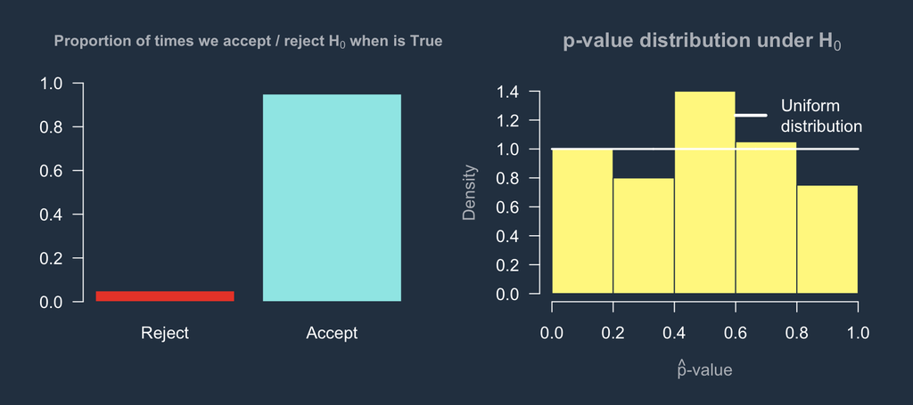

#### Comments

In the simulation above we are in a scenario where $n_{0} = n{1} = 70$, the dimensionality $k = 5$, and the simulation size $P = 100$ and we are dealing with the goodness of fit hypothesis test. The first plot shows the empirical size $\alpha \approx 0.05$ and the second one show the distribution of the observed $\hat{p}$ values with the theoretical $Unif(0,1)$ distribution. Increasing $P$ the histograms would fit better with the theoretical distribution.

The real goal of this type of simulation is to see how an algorithm would perform w.r.t to metrics as size and power while changing input parameters as $n_{0}, n_{1}, k$.

#### Performance with rispect to the size $\alpha$

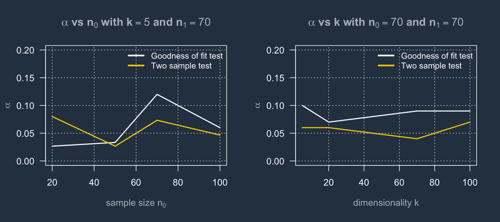

```r
# Changing n0.
n0s <- c(20,50,70,100)   # Values of alpha tested
k <- 5                   # Set the dimensionality as 5
P <- 150
alpha_Friedmann <- rep(NA ,length(n0s))    # Preset the empirical alpha
alpha_per <- rep(NA , length(n0s))         # Preset the empirical alpha
for(i in 1:length(n0s)){
  n0 <- n0s[i]
  alpha_Friedmann[i] <- 1-mean(alpha_info(P)$KS)
  alpha_per[i] <- 1-mean(alpha_info(P,permut = T)$KS)
}

# Changing k.
ks <- c(5,20,70,100)
P <- 150
n0 <- 70
n1 <- 70
alpha_permutation_2 <- rep(NA ,length(ks))
alpha_Friedmann_2 <- rep(NA ,length(ks))
for(i in 1:length(ks)){
  print(i)
  k <- ks[i]
  mu <- rep(0,k)
  sigma <- diag(1,k)
  alpha_permutation_2[i] <- 1-mean(alpha_info(P)$KS)
  alpha_Friedmann_2[i] <- 1-mean(alpha_info(P,permut = T)$KS)
  }
```

### Performance with rispect to the power $1 - \beta$

To get out information about the power of the test (probability to get a correct discovery) we set up a simulation generating sample from difference distribution to check how likely it is that our test rejects $H_{0}$ when it is false. We set up different scenarios where $F_{x} \neq F_{z}$ and count how many times we reject the null hypothesis. Of course, if the two distributions are close to each other is more difficult to discover the difference and reject $H_{0}$ then. If the two distributions are far to each other, it would be easier for the test detect the differences and reject $H_{0}$ then.

In the simulation study we choose Gaussian parametric family for both $F_{x}$ and $F_{z}$, let change the $F_{z}$ position parameters $\underline{\mu}$ since it possible to compute a closed-form of Wasserstein distance of two distributions for two multivariate normal distributions $D(F_{x},F_{z}) = D(\underline{\mu_{x}} ,\underline{\mu_{z}})$ .
$$\boldsymbol{X} \sim \mathrm{N}_k(\boldsymbol{\mu}_1, \Sigma_1)
\hspace{.3cm}
\boldsymbol{Y} \sim \mathrm{N}_k(\boldsymbol{\mu}_2, \Sigma_2)$$

$$\textsf{W}^2_2(\boldsymbol{X}, \boldsymbol{Y}) = \| \boldsymbol{\mu}_1 -
\boldsymbol{\mu}_2\|_2^2 + \mathrm{B}^2(\Sigma_1, \Sigma_2)$$

```r
# Distance functions.
beta_q <- function(sigma1, sigma2){
  trace_1 <- tr(sigma)    # Trace of sigma X
  trace_2 <- tr(sigma2)   # Trace of sigma Y
  trace_3 <- tr(sqrtm(sqrtm(sigma1)$B %*% sigma2 %*% sqrtm(sigma1)$B)$B)

  return(trace_1 + trace_2 - 2*trace_3)
}

Wasserstein_distance <- function(mu1, mu2, sigma1, sigma2){
  norma <- norm(mu1-mu2, type = "2")**2
  beta_quadro <- beta_q(sigma1, sigma2)

  return(norma + beta_quadro)
}

power_info <- function(P, k, increment , permut = F){

  prop_ks <- rep(NA, P)    # Pre-set proportions of accept/reject
  for(i in 1:P){
    x <- Take_sample_normal(n = n0, mu= mu, sigma = sigma, label = 0)  # Take sample of x
    z <- Take_sample_normal(n = n1, mu=  mu2, sigma = sigma2, label = 1) # Take sample of z (From a different distribution)
    u <- rbind(x,z)    # Combine the dataset
    p_model <- glm(label ~ ., data = u)   # Perform the obs model
    x_scores <- predict(p_model, x)       # Predict the obs scores
    z_scores <- predict(p_model, z)       # ""
    kolm_obs <- ks.test(x_scores, z_scores, alternative = "two.sided")$statistic                    # Obs statistic
    if(permut == FALSE){
      kk <- Friedman_procedure(P,x_data = x, z_data = z)
    }
    if(permut == TRUE){
      kk <- Friedman_procedure(P,x_data = x, z_data = z , permut = T)
    }

    prop_ks[i] <- kolm_obs > quantile(kk,1-alpha)
  }
  data <-  mean(prop_ks)


  return(data)
}
```

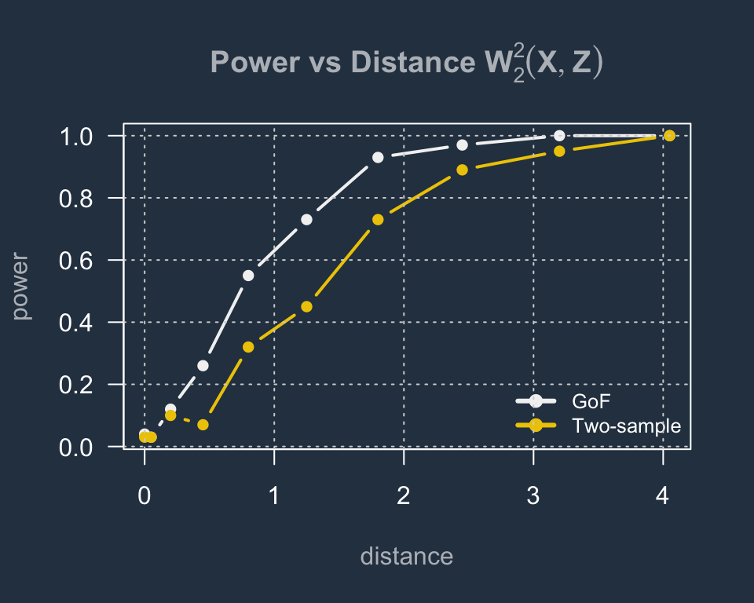

##### Comments

In the Goodness of fit hypothesis testing we use the additional information of the distribution of $F_{z} = F$, such of that, this procedure has the potential to increase the power of the test. However, in the real application when our knowledge is as limited knowing only the sample and, so to perform goodness of fit test we need to assume a reference distribution for the sample. This can be done with using past knowledge and studies. In our case, we will remain in the context of two sample hypothesis test.

#### Test power vs sample size and test power vs dimensionality

The test’s usefulness is based on its ability to distinguish among a diverse range of alternative hypotheses. In this section, we present the outcomes of different simulation studies that investigate the test’s power for various alternative hypotheses across multiple dimensions.

We focus our studies on the context of two sample hypothesis test. We set in different scenarios, where based on our knowledge simulation, the sample $\underline{x}$ came from a $F_{1} \sim N(\underline{\mu_{1}},\Sigma)$ and the sample $\underline{z}$ came from a $F_{2} \sim N(\underline{\mu_{2}},\Sigma)$ with different $\underline{\mu_{2}}$. Greater the distance from $\underline{\mu_{1}}$ and $\underline{\mu_{2}}$, the more separated will be the two distributions we are comparing, and so in all likelihood, the test can detect the differences better. Specifically, we tweak the parameter $n_{0}$ and $k$ to get information about how the power varies with the distance and with the parameter values.

The plot on the left show how the power change according to the distance, let varying the sample size $n_{0}$.

The plot on the right show how the power change according to the distance, let varying the dimensionality $k$.

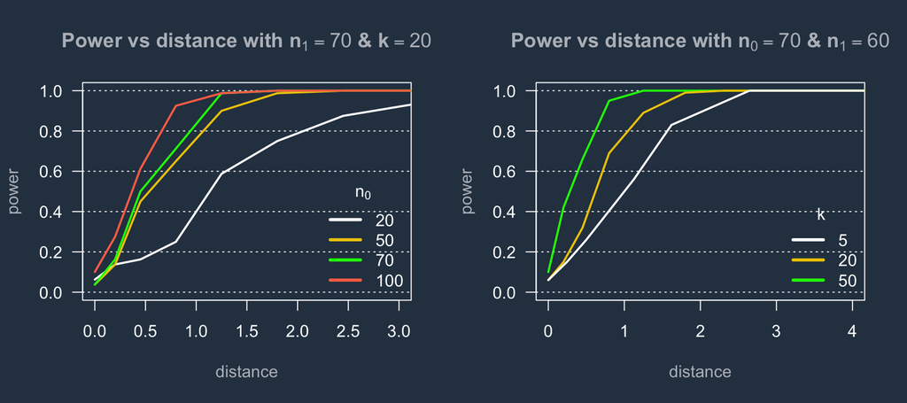